# House Selling Prices

The goal of this assignment was to create a model that accurately predicts house selling prices. To start my analysis I ran an lm for each variable with “SalePrice” and made note of the highest $R^2$’s (.3 and up). I summed each of those all together in a model and got a pretty high $R^2$ of around .83.

I will now walk through the rest of the steps I took to get my lm.

## Box-Cox

### Box-Cox

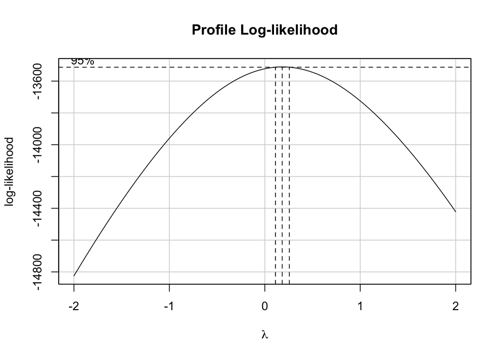

```r
boxCox(lm)
```

## Interaction Plots

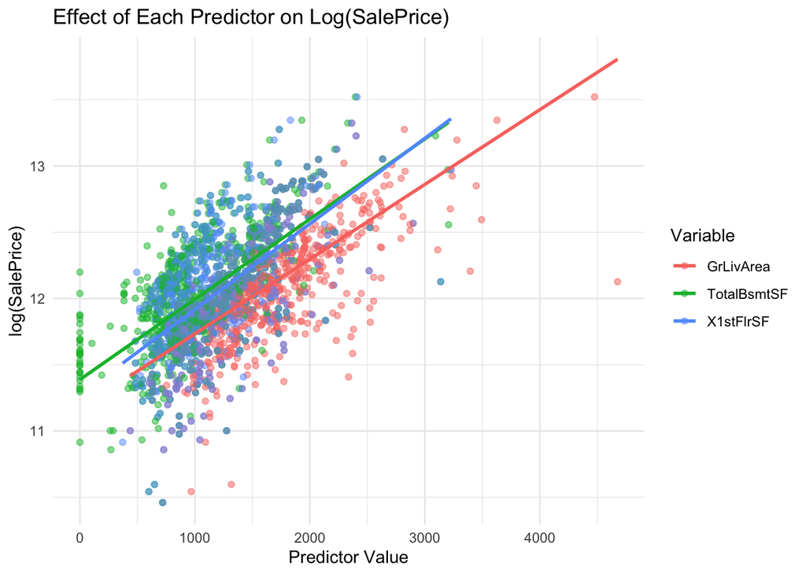

```r
library(ggplot2)
library(dplyr)
library(tidyr)


plot_data <- mytrain %>%
  dplyr::select(SalePrice, GrLivArea, TotalBsmtSF, X1stFlrSF) %>%
  tidyr::pivot_longer(cols = -SalePrice, names_to = "Variable", values_to = "Value")
#, KitchenQual, YearBuilt

# Plot each variable’s effect on SalePrice in one graph
ggplot(plot_data, aes(x = Value, y = log(SalePrice), color = Variable)) +
  geom_point(alpha = 0.5) +
  geom_smooth(method = "lm", formula = y~x,se = FALSE) +  # Add separate regression lines
  #facet_wrap(~Variable, scales = "free_x") + # Optional: separate plots per variable
  labs(title = "Effect of Each Predictor on Log(SalePrice)",
       x = "Predictor Value",
       y = "log(SalePrice)") +
  theme_minimal()
```

I also decided to graph each of the variables that had similar x axis limits to visually show their correlation. In this plot we can see GrLivArea, TotalBsmtSF, and X1stFlrSF have pretty similar slope. I decided to try interacting each one with another in my lm and when I added TotalBsmtSF:GrLivArea + GrLivArea:X1stFlrSF it made my $R^2$ higher!

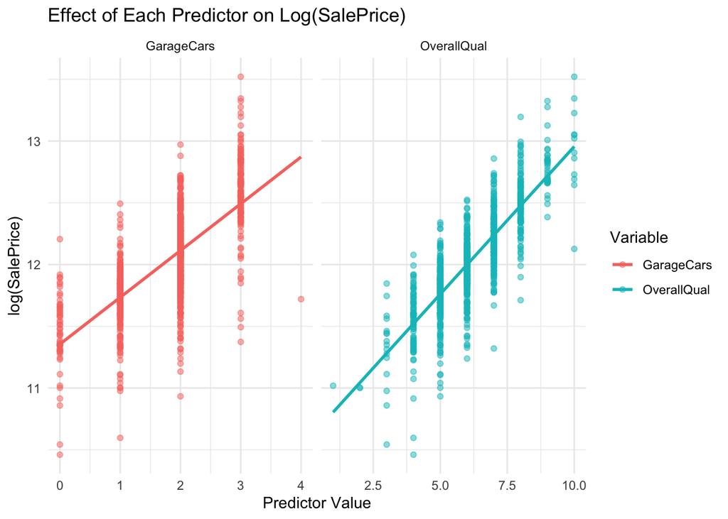

```r
plot_data <- mytrain %>%
  dplyr::select(SalePrice, GarageCars, OverallQual) %>%
  tidyr::pivot_longer(cols = -SalePrice, names_to = "Variable", values_to = "Value")
#, KitchenQual, YearBuilt

# Plot each variable’s effect on SalePrice in one graph
ggplot(plot_data, aes(x = Value, y = log(SalePrice), color = Variable)) +
  geom_point(alpha = 0.5) +
  geom_smooth(method = "lm",formula = y~x, se = FALSE) +
  facet_wrap(~Variable, scales = "free_x") +
  labs(title = "Effect of Each Predictor on Log(SalePrice)",
       x = "Predictor Value",
       y = "log(SalePrice)") +
  theme_minimal()
```

From the plots above I tried the interaction between Garage Cars and Overall Qual. I found that the result wasn’t significant and so I didn’t keep it. As seen above, their graphs are pretty different and it looks like they are not very meaninful together so I wasn’t surprised when their interaction wasn’t significant.

I also tried interacting a few other variables I guessed would be correlated and found that as.factor(Neighborhood):OverallQual also helped my models $R^2$.

## Final lm

#### Final R-Squareds and Validation R-Squareds

```r
yht <- predict(lm, newdata= mytest)
yht <- na.omit(yht)
  # Compute y-bar
ybar <- mean(log(mytest$SalePrice))

  # Compute SSTO
SSTO <- sum( (log(mytest$SalePrice) - ybar)^2 )

  # Compute SSE for each model using y - yhat
SSEl <- sum( (log(mytest$SalePrice) - yht)^2 )

  # Compute R-squared for each
rsl <-  1-(SSEl/SSTO)

  # Compute adjusted R-squared for each
n <- length(mytest$SalePrice) #sample size
pl <- length(coef(mytrain))
rstal<- 1-(n-1)/(n-pl)*SSEl/SSTO

my_output_table2 <- data.frame(Model = c("True"), `Original R2` = c(summary(lm)$r.squared), `Orig. Adj. R-squared` = c(summary(lm)$adj.r.squared), `Validation R-squared` = c(rsl), `Validation Adj. R^2` = c(rstal))

colnames(my_output_table2) <- c("Model", "Original $R^2$", "Original Adj. $R^2$", "Validation $R^2$", "Validation Adj. $R^2$")

knitr::kable(my_output_table2, escape=TRUE, digits=4)
```

| Model | Original $R^2$ | Original Adj. $R^2$ | Validation $R^2$ | Validation Adj. $R^2$ |
| --- | --- | --- | --- | --- |
| True | 0.8804 | 0.8731 | 0.876 | 0.8763 |

```r
lm<- lm(log(SalePrice)~GrLivArea + KitchenQual  + GarageCars + TotalBsmtSF  +  (Neighborhood) + (Neighborhood):OverallQual +  X1stFlrSF + YearBuilt +  TotalBsmtSF:GrLivArea + GrLivArea:X1stFlrSF, data = mytrain)
summary(lm)
```

```
##
## Call:
## lm(formula = log(SalePrice) ~ GrLivArea + KitchenQual + GarageCars +
##     TotalBsmtSF + (Neighborhood) + (Neighborhood):OverallQual +
##     X1stFlrSF + YearBuilt + TotalBsmtSF:GrLivArea + GrLivArea:X1stFlrSF,
##     data = mytrain)
##
## Residuals:
##      Min       1Q   Median       3Q      Max
## -0.77071 -0.06724  0.00856  0.08619  0.43008
##
## Coefficients: (2 not defined because of singularities)
##                                   Estimate Std. Error t value Pr(>|t|)
## (Intercept)                      5.862e+00  1.121e+00   5.230 2.09e-07 ***
## GrLivArea                        4.030e-04  2.785e-05  14.469  < 2e-16 ***
## KitchenQualFa                   -2.039e-01  4.074e-02  -5.005 6.65e-07 ***
## KitchenQualGd                   -1.085e-01  2.421e-02  -4.481 8.35e-06 ***
## KitchenQualTA                   -1.697e-01  2.690e-02  -6.310 4.29e-10 ***
## GarageCars                       5.116e-02  9.338e-03   5.479 5.49e-08 ***
## TotalBsmtSF                      2.196e-04  5.968e-05   3.680 0.000247 ***
## NeighborhoodBlueste              7.962e-01  8.466e-01   0.941 0.347194
## NeighborhoodBrDale               8.639e-01  9.572e-01   0.902 0.367027
## NeighborhoodBrkSide              2.333e-01  8.416e-01   0.277 0.781652
## NeighborhoodClearCr              2.498e-01  8.623e-01   0.290 0.772127
## NeighborhoodCollgCr              7.132e-01  8.394e-01   0.850 0.395715
## NeighborhoodCrawfor              4.960e-01  8.476e-01   0.585 0.558611
## NeighborhoodEdwards              6.384e-01  8.375e-01   0.762 0.446033
## NeighborhoodGilbert              6.511e-01  8.515e-01   0.765 0.444631
## NeighborhoodIDOTRR              -2.188e-01  8.487e-01  -0.258 0.796585
## NeighborhoodMeadowV              5.644e-01  8.802e-01   0.641 0.521510
## NeighborhoodMitchel              6.084e-01  8.579e-01   0.709 0.478366
## NeighborhoodNAmes                5.506e-01  8.380e-01   0.657 0.511299
## NeighborhoodNoRidge              2.310e-02  8.784e-01   0.026 0.979028
## NeighborhoodNPkVill              8.495e-01  8.353e-01   1.017 0.309388
## NeighborhoodNridgHt              2.067e-01  8.472e-01   0.244 0.807332
## NeighborhoodNWAmes               1.016e+00  8.619e-01   1.179 0.238838
## NeighborhoodOldTown              3.619e-01  8.373e-01   0.432 0.665689
## NeighborhoodSawyer               3.997e-01  8.620e-01   0.464 0.642986
## NeighborhoodSawyerW              2.821e-01  8.474e-01   0.333 0.739259
## NeighborhoodSomerst              5.049e-01  8.491e-01   0.595 0.552287
```

[output cut: 24 more lines]

```
## NeighborhoodSawyer:OverallQual   9.064e-02  4.279e-02   2.118 0.034396 *
## NeighborhoodSawyerW:OverallQual  9.804e-02  2.407e-02   4.073 5.04e-05 ***
## NeighborhoodSomerst:OverallQual  6.888e-02  2.371e-02   2.904 0.003765 **
## NeighborhoodStoneBr:OverallQual  1.163e-01  5.618e-02   2.071 0.038651 *
## NeighborhoodSWISU:OverallQual    7.994e-02  3.113e-02   2.568 0.010383 *
## NeighborhoodTimber:OverallQual   5.423e-02  2.208e-02   2.456 0.014228 *
## NeighborhoodVeenker:OverallQual  8.554e-02  3.562e-02   2.402 0.016510 *
## GrLivArea:TotalBsmtSF           -5.389e-08  3.422e-08  -1.575 0.115587
## GrLivArea:X1stFlrSF             -7.153e-08  3.716e-08  -1.925 0.054500 .
## ---
## Signif. codes:  0 '***' 0.001 '**' 0.01 '*' 0.05 '.' 0.1 ' ' 1
##
## Residual standard error: 0.1455 on 942 degrees of freedom
## Multiple R-squared:  0.8804, Adjusted R-squared:  0.8731
## F-statistic: 121.6 on 57 and 942 DF,  p-value: < 2.2e-16
```

## Graphing my Final lm:

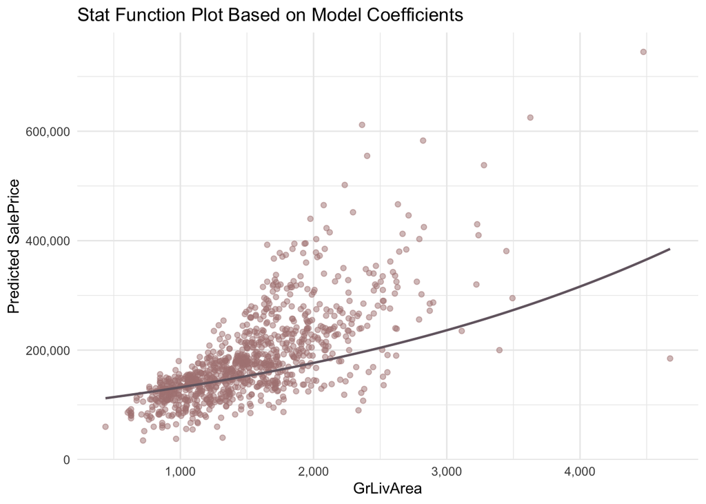

```r
b<-coef(lm)
library(ggplot2)

ggplot(mytrain, aes(x = GrLivArea, y = SalePrice)) +
  geom_point(alpha = 0.5, color = "#af8382") +

  stat_function(fun = function(GrLivArea) {
    KitchenQualTA = 1
    GarageCars = 2
    TotalBsmtSF = 750
    NeighborhoodNAmes = 1
    X1stFlrSF = 1000
    YearBuilt = 2006
    OverallQual = 5

    exp(b[1] +
        b[2]*GrLivArea +
        b[3]*KitchenQualTA +
        b[6]*GarageCars +
        b[7]*TotalBsmtSF +
        b[19]*NeighborhoodNAmes +
        b[32]*X1stFlrSF +
        b[33]*YearBuilt +
        b[46]*NeighborhoodNAmes*OverallQual +
        b[59]*GrLivArea*TotalBsmtSF +
        b[60]*GrLivArea*X1stFlrSF)
  }, color = "#746770", size = 0.8) +

  labs(title = "Stat Function Plot Based on Model Coefficients",
       x = "GrLivArea",
       y = "Predicted SalePrice") +

  scale_y_continuous(labels = scales::comma) +
  scale_x_continuous(labels = scales::comma) +

  theme_minimal()
```

This graph shows the relationship between GrLivArea and SalePrice using actual data points and predicted values from my linear model. The curve shows how the model expects sale prices to change as GrLivArea increases.